# Project Proposal

Brandon Parmanand

2022-06-27

```r
# Clear workspace.
rm(list=ls(all=TRUE))

# Set Working Directory
wdpath <- ("~/GitHub/Parmanand STA5104 Project")
setwd(wdpath)

# Intall needed libraries
library(tidyverse)
```

```r
library(ggplot2)
library(GGally)
#Read in Data
Movies.df <- read_csv("movies.csv")
```

```
## * `` -> ...1
```

# Data Description

The dataset contains 651 instances of movies released in theaters between the period of 1970 – 2014. The variables of the data set include IMBD ratings, rotten tomatoes critics and audience ratings and scores, actors and directors, movie runtime, genre, releases dates, award nominations and wins, and more. Some variables will be deleted as it has no value to my intended statistical analysis such as the list of actors.

```r
# Do some initial data exploration such as simple observations for range of
# release years, dimensions, and column names
dim(Movies.df)
```

```
## [1] 651  33
```

```r
range(Movies.df$thtr_rel_year)
```

```
## [1] 1970 2014
```

```r
t(t(names(Movies.df)))
```

```
##       [,1]
##  [1,] "...1"
##  [2,] "title"
##  [3,] "title_type"
##  [4,] "genre"
##  [5,] "runtime"
##  [6,] "mpaa_rating"
##  [7,] "studio"
##  [8,] "thtr_rel_year"
##  [9,] "thtr_rel_month"
## [10,] "thtr_rel_day"
## [11,] "dvd_rel_year"
## [12,] "dvd_rel_month"
## [13,] "dvd_rel_day"
## [14,] "imdb_rating"
```

[output cut: 19 more lines]

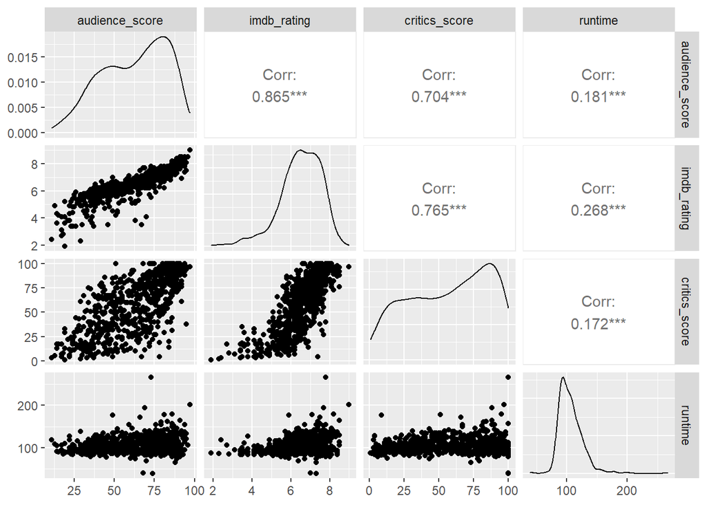

```r
# Do some correlation outlook using scatter plot matrix
ggpairs(Movies.df[, c('audience_score', 'imdb_rating', 'critics_score',
                      'runtime')])
```

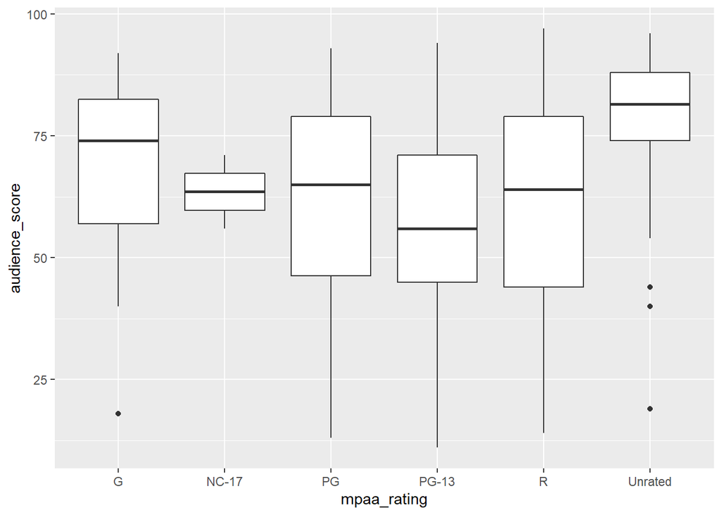

```r
# Look at correlation between MPAA rating and Audience score
ggplot(Movies.df, aes(x = mpaa_rating, y = audience_score)) +
  geom_boxplot()
```

## Target Problem

Is there a correlation between the critic score and audience score? Or genre and the audience score? How about MPAA rating and audience score? My target problem is to find what variables affect the audience score and whether we can predict the audience score using the variables such as genre, critic rating, IMBD rating, release date, and runtime.

## Statistical Problem

My statistical problem will using the given variables such as genre, MPAA rating, release dates, IMBD rating, and critic scores to predict the audience score.

## Proposed Statistical Analysis

My proposed statistical analysis will be using a linear regression model to predict the audience score of the movies. Some initial research shows that there can be minimal correlation between certain variables to the audience score such as movie runtime.